# Een blik op de recensies van hotels in Amsterdam

Nadine Allewijn (11027541), Thomas Dijkman (11026057) Andrea Pineda (10590501) & Gavin Schipper (11027592)

- **Onderzoeksvraag: Wat voor conclusies kunnen uit reviews van hotels in Amsterdam worden getrokken?**
  - Is er een verband tussen de lengte van de reviews en het cijfer dat wordt gegeven?
  - Kunnen we het sentiment van een reviews voorspellen aan de hand van de gebruikte woorden? Oftewel; positiviteit of negativiteit.
  - Zijn er verschillen in cijfers tussen de Amsterdamse buurten?
- Data is afkomstig van Booking.com. Het bevat 515K regels aan reviews en scores van bijna 1500 hotels in het wat luxere segment in Europa.

## Literatuur

- Reden van dit onderzoek:
  - steeds aantrekkelijker om aan de hand van 'user generated data' (oftewel de reviews) inzicht te krijgen in problemen in de hotelwereld. Hierop kon met 'normaal' onderzoek geen antwoord worden gegeven (Ye et al., 2009). Het kan namelijk nieuwe inzichten bieden (Xiang et al., 2015).
  - er is een significante relatie tussen online reviews en het aantal boekingen van hotelkamers (Ye et al., 2009). Reviews zijn dus erg belangrijk en daarom interessant om te analyseren.
- Ook interessant (Mankad et al., 2016):
  - Negatieve reviews bevatten minder onderwerpen dan positieve reviews.
  - Negatieve reviews hebben meer impact dan positieve reviews.
  - Negatieve reviews hebben meer verschil in sentiment dan positieve reviews.

## Code

### Data inlezen en voorbereiden

```python
# Eerste 5 rijen
reviews.head()
```

|  | Hotel Address | Average Score | Hotel Name | Reviewer Nationality | Negative Review | Length Negative Review | Positive Review | Length Positive Review | Reviewer Score |
| --- | --- | --- | --- | --- | --- | --- | --- | --- | --- |
| 0 | s Gravesandestraat 55 Oost 1092 AA Amsterdam ... | 7.7 | Hotel Arena | Russia | I am so angry that i made this post available... | 397 | Only the park outside of the hotel was beauti... | 11 | 2.9 |
| 1 | s Gravesandestraat 55 Oost 1092 AA Amsterdam ... | 7.7 | Hotel Arena | Ireland | No Negative | 0 | No real complaints the hotel was great great ... | 105 | 7.5 |
| 2 | s Gravesandestraat 55 Oost 1092 AA Amsterdam ... | 7.7 | Hotel Arena | Australia | Rooms are nice but for elderly a bit difficul... | 42 | Location was good and staff were ok It is cut... | 21 | 7.1 |
| 3 | s Gravesandestraat 55 Oost 1092 AA Amsterdam ... | 7.7 | Hotel Arena | United Kingdom | My room was dirty and I was afraid to walk ba... | 210 | Great location in nice surroundings the bar a... | 26 | 3.8 |
| 4 | s Gravesandestraat 55 Oost 1092 AA Amsterdam ... | 7.7 | Hotel Arena | New Zealand | You When I booked with your company on line y... | 140 | Amazing location and building Romantic setting | 8 | 6.7 |

```python
# Alleen de recensies over hotels in Amsterdam
amsterdam = reviews[reviews['Hotel Address'].str.contains("Amsterdam Netherlands")]

# Aantal hotels in Amsterdam in deze dataset
len(amsterdam['Hotel Name'].unique())
```

```
105
```

## 1. Bestaat er een relatie tussen aantal woorden en positiviteit?

Klopt het dat hoe minder woorden er worden gebruikt, hoe positiever de recensie is?

```python
# Kolom toevoegen met de lengte van de totale review
amsterdam['Length Total Review'] = (amsterdam['Length Negative Review']+amsterdam['Length Positive Review'])
```

```
De correlatie tussen het aantal woorden en het cijfer = -0.168920682523
```

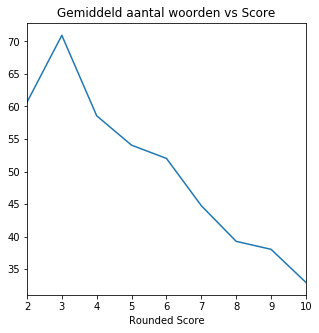

```python
amsterdam.groupby('Rounded Score')['Length Total Review'].mean().plot(figsize=(5,5), title = "Gemiddeld aantal woorden vs Score")

print("De correlatie tussen het aantal woorden en het cijfer =", amsterdam['Length Total Review'].corr(amsterdam['Reviewer Score']))
```

## 2. Kunnen we het sentiment van een recensie voorspellen aan de hand van de gebruikte woorden?

### Sentiment analysis

- Wat voor woorden worden er gebruikt bij negatieve reviews?
- En bij positieve reviews?
- Kan aan de hand van de woorden die gebruikt worden voorspeld worden of een nieuwe review overwegend positief of negatief is?
  - Dit kan interessant zijn om automatisch review(delen) te categoriseren.

```python
# Deze functie maakt van een string een wordcloud met de bijvoeglijke naamwoorden die voorkomen in de string

def adj_wordcloud(string):
    tokens = nltk.word_tokenize(string)
    tags = nltk.pos_tag(tokens)

    #Hier selecteren we alle bijvoeglijke naamwoorden
    adjectives = " ".join([word[0] for word in tags if word[1] == "JJ" and word[0] != 'i'])

    wordcloud = WordCloud(font_path='/Library/Fonts/Arial.ttf',
                      background_color='white',
                      colormap="Blues",
                      max_words=200,
                      max_font_size=40,
                      scale=3,
                      stopwords = set(stopwords.words('english'))
                      ).generate(adjectives)
    fig = plt.figure(1, figsize=(12, 12))

    plt.imshow(wordcloud)
    plt.axis("off")
    plt.show()
```

### Wat voor woorden worden er gebruikt bij negatieve reviews?

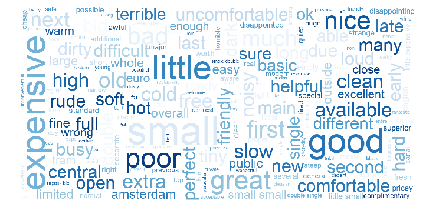

```python
adj_wordcloud(review_str_neg)
```

### En bij positieve reviews?

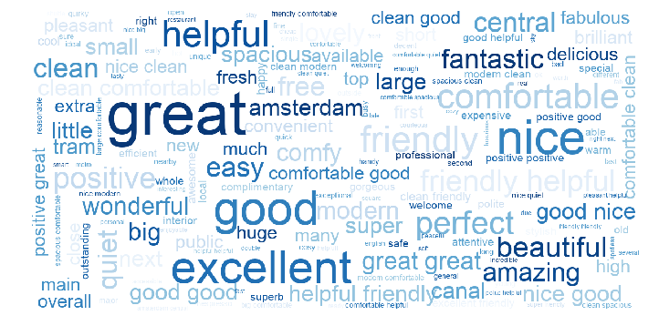

```python
adj_wordcloud(review_str_pos)
```

### Kan aan de hand van de woorden die gebruikt worden voorspeld worden of een nieuwe review overwegend positief of negatief is?

```python
# We trainen een Naive Bayes Classifier met de reviews die we hebben

import nltk.classify.util
from nltk.classify import NaiveBayesClassifier

def word_feats(text):
    tokenized = nltk.word_tokenize(text)
    return dict([(word, True) for word in tokenized])

negreviews = amsterdam['Negative Review']
posreviews = amsterdam['Positive Review']

negfeats = [(word_feats(f), 'neg') for f in negreviews]
posfeats = [(word_feats(f), 'pos') for f in posreviews]

negcutoff = int(len(negfeats)*3/4)
poscutoff = int(len(posfeats)*3/4)

trainfeats = negfeats[:negcutoff] + posfeats[:poscutoff]
testfeats = negfeats[negcutoff:] + posfeats[poscutoff:]
print(len(trainfeats), len(testfeats))

classifier = NaiveBayesClassifier.train(trainfeats)
print('accuracy:', nltk.classify.util.accuracy(classifier, testfeats))
```

```
85820 28608
accuracy: 0.9307536353467561
```

```python
# De eerste vijf regels van het DataFrame met de nieuwe kolom 'predicted'

amsterdam.head()
```

|  | Hotel Address | Average Score | Hotel Name | Reviewer Nationality | Negative Review | Length Negative Review | Positive Review | Length Positive Review | Reviewer Score | Length Total Review | Rounded Score | Total Review | Predicted |
| --- | --- | --- | --- | --- | --- | --- | --- | --- | --- | --- | --- | --- | --- |
| 0 | s Gravesandestraat 55 Oost 1092 AA Amsterdam ... | 7.7 | Hotel Arena | Russia | I am so angry that i made this post available... | 397 | Only the park outside of the hotel was beauti... | 11 | 2.9 | 408 | 3.0 | I am so angry that i made this post available... | neg |
| 1 | s Gravesandestraat 55 Oost 1092 AA Amsterdam ... | 7.7 | Hotel Arena | Ireland | No Negative | 0 | No real complaints the hotel was great great ... | 105 | 7.5 | 105 | 8.0 | No Negative No real complaints the hotel was g... | neg |
| 2 | s Gravesandestraat 55 Oost 1092 AA Amsterdam ... | 7.7 | Hotel Arena | Australia | Rooms are nice but for elderly a bit difficul... | 42 | Location was good and staff were ok It is cut... | 21 | 7.1 | 63 | 7.0 | Rooms are nice but for elderly a bit difficul... | neg |
| 3 | s Gravesandestraat 55 Oost 1092 AA Amsterdam ... | 7.7 | Hotel Arena | United Kingdom | My room was dirty and I was afraid to walk ba... | 210 | Great location in nice surroundings the bar a... | 26 | 3.8 | 236 | 4.0 | My room was dirty and I was afraid to walk ba... | neg |
| 4 | s Gravesandestraat 55 Oost 1092 AA Amsterdam ... | 7.7 | Hotel Arena | New Zealand | You When I booked with your company on line y... | 140 | Amazing location and building Romantic setting | 8 | 6.7 | 148 | 7.0 | You When I booked with your company on line y... | neg |

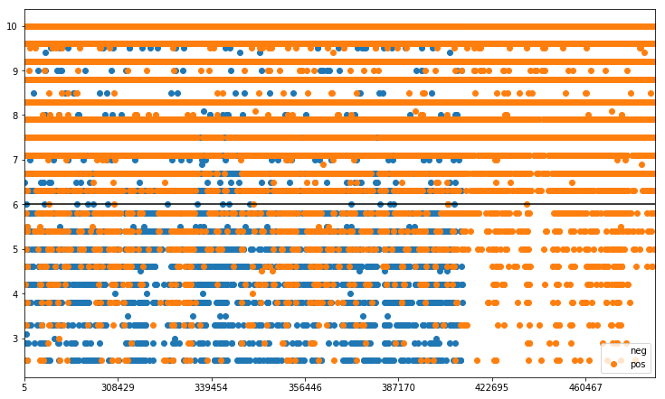

```python
# Visualisatie van het resultaat met scheidingslijn bij 6

amsterdam.groupby('Predicted')['Reviewer Score'].plot(style='o',figsize=(12.5,7.5),legend=True)
plt.plot([0,len(amsterdam)],[6,6], 'k-');
```

```python
# We berekenen het fout percentage. Hierbij nemen 6 als de grens tussen onvoldoende en voldoende

incorrect = 0

for index,row in amsterdam.iterrows():
    if float(row['Reviewer Score']) < 6.0 and row['Predicted'] == 'pos':
        incorrect += 1
    elif float(row['Reviewer Score']) >= 6.0 and row['Predicted'] == 'neg':
        incorrect += 1

print("Foutpercentage =",(incorrect/len(amsterdam)*100))
```

```
Foutpercentage = 36.30055580801901
```

## 3. Zijn er verschillen in cijfers tussen de Amsterdamse buurten?

```python
# We hebben een kolom toegevoegd waar de 4 cijfers van de postcode van het hotel in staan
amsterdam.head()
```

|  | Hotel Address | Average Score | Hotel Name | Reviewer Nationality | Negative Review | Length Negative Review | Positive Review | Length Positive Review | Reviewer Score | Length Total Review | Rounded Score | Total Review | Predicted | Zip Code |
| --- | --- | --- | --- | --- | --- | --- | --- | --- | --- | --- | --- | --- | --- | --- |
| 0 | s Gravesandestraat 55 Oost 1092 AA Amsterdam ... | 7.7 | Hotel Arena | Russia | I am so angry that i made this post available... | 397 | Only the park outside of the hotel was beauti... | 11 | 2.9 | 408 | 3.0 | I am so angry that i made this post available... | neg | 1092 |
| 1 | s Gravesandestraat 55 Oost 1092 AA Amsterdam ... | 7.7 | Hotel Arena | Ireland | No Negative | 0 | No real complaints the hotel was great great ... | 105 | 7.5 | 105 | 8.0 | No Negative No real complaints the hotel was g... | neg | 1092 |
| 2 | s Gravesandestraat 55 Oost 1092 AA Amsterdam ... | 7.7 | Hotel Arena | Australia | Rooms are nice but for elderly a bit difficul... | 42 | Location was good and staff were ok It is cut... | 21 | 7.1 | 63 | 7.0 | Rooms are nice but for elderly a bit difficul... | neg | 1092 |
| 3 | s Gravesandestraat 55 Oost 1092 AA Amsterdam ... | 7.7 | Hotel Arena | United Kingdom | My room was dirty and I was afraid to walk ba... | 210 | Great location in nice surroundings the bar a... | 26 | 3.8 | 236 | 4.0 | My room was dirty and I was afraid to walk ba... | neg | 1092 |
| 4 | s Gravesandestraat 55 Oost 1092 AA Amsterdam ... | 7.7 | Hotel Arena | New Zealand | You When I booked with your company on line y... | 140 | Amazing location and building Romantic setting | 8 | 6.7 | 148 | 7.0 | You When I booked with your company on line y... | neg | 1092 |

```python
def neighbours(row):
    if 1011 <= row['Zip Code'] <= 1018:
        return "Centrum"
    elif 1020 <= row['Zip Code'] <= 1039:
        return "Noord"
    elif 1040 <= row['Zip Code'] <= 1069:
        return "West"
    elif 1070 <= row['Zip Code'] <= 1083:
        return "Zuid"
    elif 1086 <= row['Zip Code'] <= 1099:
        return "Oost"
    elif row['Zip Code'] == 1019:
        return "Oost"
    elif 1100 <= row['Zip Code'] <= 1108:
        return "Zuid-Oost"
```

```python
# We voegen ook een kolom toe waar staat onder welke Amsterdamse buurt het hotel valt.

amsterdam.head()
```

|  | Hotel Address | Average Score | Hotel Name | Reviewer Nationality | Negative Review | Length Negative Review | Positive Review | Length Positive Review | Reviewer Score | Length Total Review | Rounded Score | Total Review | Predicted | Zip Code | Neighbourhood |
| --- | --- | --- | --- | --- | --- | --- | --- | --- | --- | --- | --- | --- | --- | --- | --- |
| 0 | s Gravesandestraat 55 Oost 1092 AA Amsterdam ... | 7.7 | Hotel Arena | Russia | I am so angry that i made this post available... | 397 | Only the park outside of the hotel was beauti... | 11 | 2.9 | 408 | 3.0 | I am so angry that i made this post available... | neg | 1092 | Oost |
| 1 | s Gravesandestraat 55 Oost 1092 AA Amsterdam ... | 7.7 | Hotel Arena | Ireland | No Negative | 0 | No real complaints the hotel was great great ... | 105 | 7.5 | 105 | 8.0 | No Negative No real complaints the hotel was g... | neg | 1092 | Oost |
| 2 | s Gravesandestraat 55 Oost 1092 AA Amsterdam ... | 7.7 | Hotel Arena | Australia | Rooms are nice but for elderly a bit difficul... | 42 | Location was good and staff were ok It is cut... | 21 | 7.1 | 63 | 7.0 | Rooms are nice but for elderly a bit difficul... | neg | 1092 | Oost |
| 3 | s Gravesandestraat 55 Oost 1092 AA Amsterdam ... | 7.7 | Hotel Arena | United Kingdom | My room was dirty and I was afraid to walk ba... | 210 | Great location in nice surroundings the bar a... | 26 | 3.8 | 236 | 4.0 | My room was dirty and I was afraid to walk ba... | neg | 1092 | Oost |
| 4 | s Gravesandestraat 55 Oost 1092 AA Amsterdam ... | 7.7 | Hotel Arena | New Zealand | You When I booked with your company on line y... | 140 | Amazing location and building Romantic setting | 8 | 6.7 | 148 | 7.0 | You When I booked with your company on line y... | neg | 1092 | Oost |

```python
# Aantal unieke buurten

len(amsterdam['Neighbourhood'].unique())
```

```
6
```

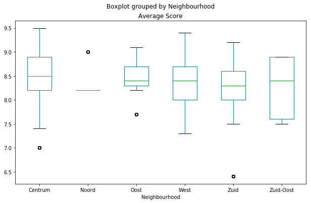

```python
# Een boxplot die de spreiding van gemiddelde scores van hotels per Amsterdamse buurt laat zien

amsterdam.boxplot(column='Average Score', by='Neighbourhood', figsize=(10,6), grid=False);
```

## Conclusie

- Is er een verband tussen de lengte van de reviews en het cijfer dat wordt gegeven?
  - Ja; de correlatie is maar -0.17, maar aan de grafiek is wel duidelijk een verband te zien.
- Kunnen we het sentiment van een reviews voorspellen aan de hand van de gebruikte woorden? Oftewel; positiviteit of negativiteit.
  - Ja; met een foutpercentage van ongeveer 36.3% is dus redelijk goed te voorspellen of een review in zijn geheel positief of negatief is.
- Zijn er verschillen in cijfers tussen de Amsterdamse buurten?
  - Ja, maar lastig te interpreteren. Medianen zijn redelijk gelijk, het is vooral de spreiding die verschilt.